# lab3

Ryan Scehovic

3/5/2021

```r
dat <- readxl::read_xls('/Users/ryans/OneDrive/Desktop/DS202/lab3/GSS.xls')
library(dplyr)
```

```r
library(ggplot2)
library(tidyverse)
dat <- dat %>% rename(year = `Gss year for this respondent`, id = `Respondent id number`, hours = `Number of hours usually work a week`,
                      marital = `Marital status`, yearSchool = `Highest year of school completed`, sex = `Respondents sex`,
                      party = `Political party affiliation`, happiness = `General happiness`, ballotUsed = `Ballot used for interview`)
```

Question #1

```r
dat %>% mutate(yearsAvg = as.numeric(yearSchool)) %>% na.omit %>% group_by(marital) %>% summarize(yearsAvg = mean(yearsAvg, na.rm = TRUE))
```

```
## # A tibble: 6 x 2
##   marital       yearsAvg
## * <chr>            <dbl>
## 1 Divorced          13.1
## 2 Married           13.0
## 3 Never married     13.4
## 4 No answer         15.5
## 5 Separated         11.9
## 6 Widowed           11.2
```

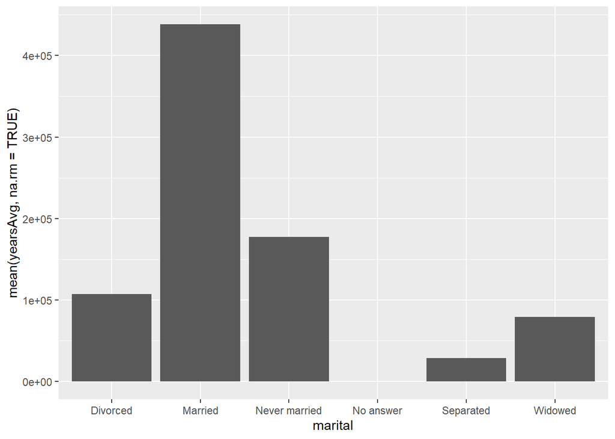

```r
dat %>% mutate(yearsAvg = as.numeric(yearSchool)) %>% na.omit %>% group_by(marital) %>% ggplot(aes(x = marital, y = mean(yearsAvg, na.rm = TRUE))) + geom_bar(stat = "identity")
```

Question #2

```r
df2 <- as.data.frame(dat)
df2 <- filter(df2, yearSchool != "Don't know" & yearSchool != 'No answer' & yearSchool != "NA" & !is.na(yearSchool))
df2$yearSchool <- as.numeric(df2$yearSchool)

df2 %>% group_by(marital) %>% summarize(meanRate = mean(yearSchool, na.rm=TRUE), sdRate = sd(yearSchool, na.rm=TRUE), numRows = n())
```

```
## # A tibble: 6 x 4
##   marital       meanRate sdRate numRows
## * <chr>            <dbl>  <dbl>   <int>
## 1 Divorced          13.1   2.91    8363
## 2 Married           13.0   3.19   34053
## 3 Never married     13.4   2.85   13801
## 4 No answer         15.5   2.84      23
## 5 Separated         11.9   3.28    2233
## 6 Widowed           11.2   3.49    6164
```

The table shows that there are the most people in the married and never married groups, the averages for both of those fall right in the middle of all the other averages which is likely due to having such a large volume it’s hard for it to sway and be an outlier, where “No Answer” had only 23 people so it’s very easy for that average to be influenced and it does end up being the largest at 15.5

Question #3

```r
df3 <- as.data.frame(dat)
str(df3)
```

```
## 'data.frame':    64816 obs. of  9 variables:
##  $ year      : num  1972 1972 1972 1972 1972 ...
##  $ id        : num  1 2 3 4 5 6 7 8 9 10 ...
##  $ hours     : chr  "Not applicable" "Not applicable" "Not applicable" "Not applicable" ...
##  $ marital   : chr  "Never married" "Married" "Married" "Married" ...
##  $ yearSchool: chr  "16" "10" "12" "17" ...
##  $ sex       : chr  "Female" "Male" "Female" "Female" ...
##  $ party     : chr  "Ind,near dem" "Not str democrat" "Independent" "Not str democrat" ...
##  $ happiness : chr  "Not too happy" "Not too happy" "Pretty happy" "Not too happy" ...
##  $ ballotUsed: chr  "Not applicable" "Not applicable" "Not applicable" "Not applicable" ...
```

```r
dfHappy <- df3 %>% group_by(marital) %>% filter(happiness=="Pretty happy" | happiness=="Very happy") %>% filter(marital!="No answer")
dfNotHappy <- df3 %>% group_by(marital) %>% filter(happiness=="Not too happy") %>% filter(marital!="No answer")

notHappy <- dfNotHappy %>% group_by(marital) %>% summarize(toalUnhappy = n())
notHappy
```

```
## # A tibble: 5 x 2
##   marital       toalUnhappy
## * <chr>               <int>
## 1 Divorced             1450
## 2 Married              2431
## 3 Never married        2055
## 4 Separated             588
## 5 Widowed              1140
```

```r
happy <- dfHappy %>% group_by(marital) %>% summarize(totalHappy = n())
happy
```

```
## # A tibble: 5 x 2
##   marital       totalHappy
## * <chr>              <int>
## 1 Divorced            6180
## 2 Married            29342
## 3 Never married      10686
## 4 Separated           1487
## 5 Widowed             4675
```

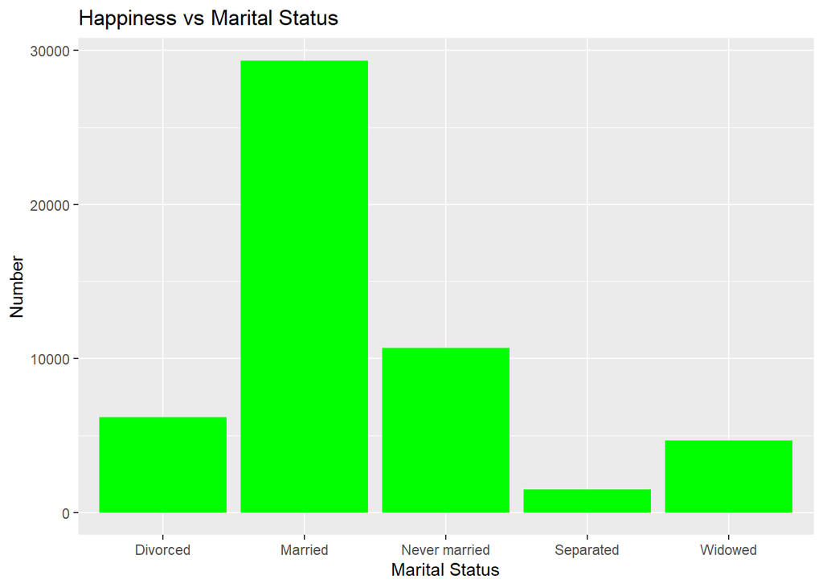

```r
ggplot(dfHappy, aes(x=marital)) + geom_bar(fill="green") + ggtitle("Happiness vs Marital Status")+xlab("Marital Status")+ylab("Number")
```

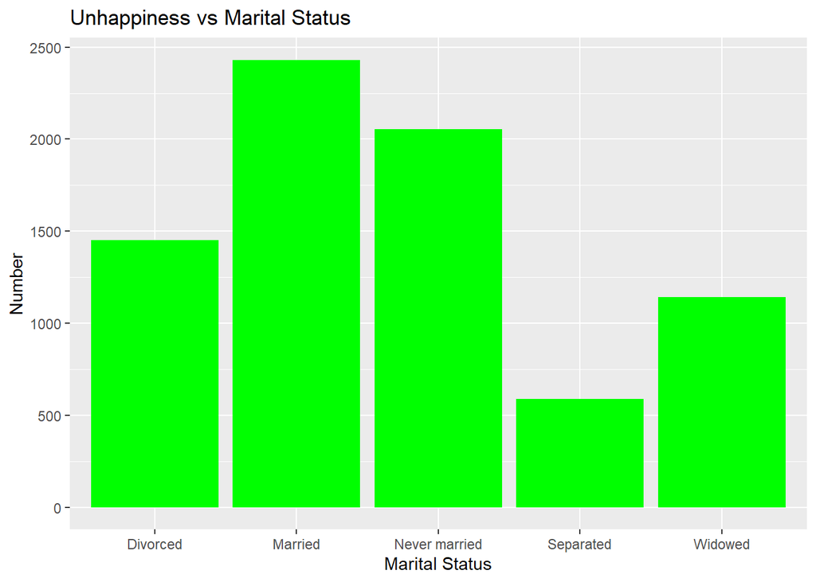

```r
ggplot(dfNotHappy, aes(x=marital)) + geom_bar(fill="green")  + ggtitle("Unhappiness vs Marital Status")+xlab("Marital Status")+ylab("Number")
```

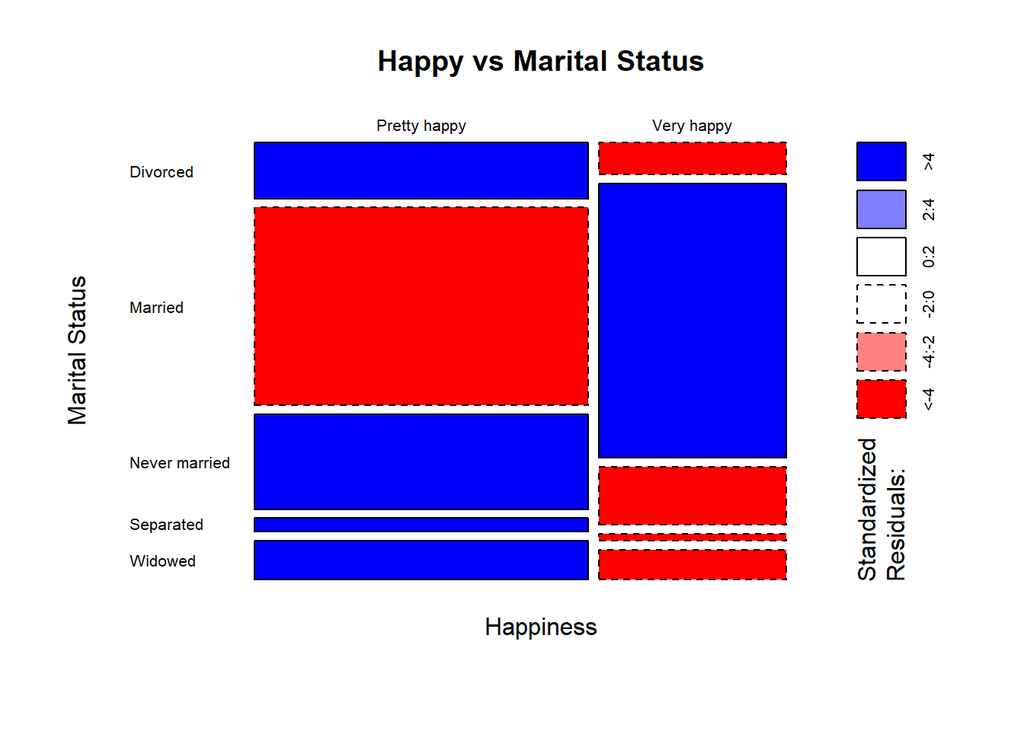

```r
mosaicplot(dfHappy$happiness~dfHappy$marital, shade=TRUE, las=1, main="Happy vs Marital Status", xlab="Happiness", ylab="Marital Status")
```

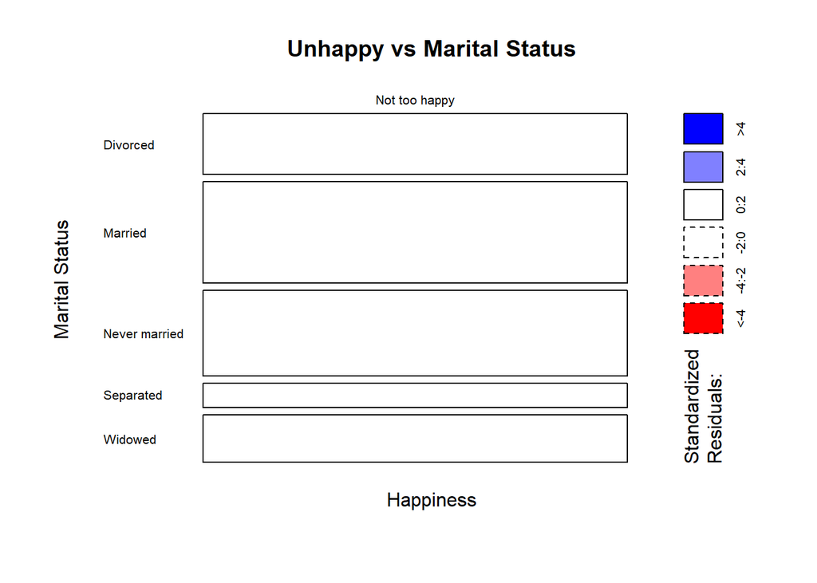

```r
mosaicplot(dfNotHappy$happiness~dfNotHappy$marital, shade=TRUE, las=1, main="Unhappy vs Marital Status", xlab="Happiness", ylab="Marital Status")
```

The graphs show the happy and happiness compared to the marital status of the person. There are a lot more happy people than unhappy which means that even if people ended up getting divorced or never married, they are happy with their decision. The last 2 graphs show that the most happy people are the ones with a marital status of married, while the other groups (Divorced, Never Married, Seperated, and Widowed) all have larger Pretty Happy amounts than Very Happy, so although they are still happy, they tend to not be as happy as married people.

Question #4

```r
unique(dfHappy$party)
```

```
##  [1] "Independent"        "Strong democrat"    "Ind,near dem"
##  [4] "Not str republican" "Ind,near rep"       "Not str democrat"
##  [7] "Strong republican"  "Other party"        "No answer"
## [10] "Don't know"
```

```r
dfiHappy<- dfHappy %>% group_by(marital) %>% filter(party=="Independent" | party=="Ind,near rep" | party=="Ind,near dem")
dfiHappy
```

```
## # A tibble: 18,564 x 9
## # Groups:   marital [5]
##     year    id hours    marital   yearSchool sex    party  happiness ballotUsed
##    <dbl> <dbl> <chr>    <chr>     <chr>      <chr>  <chr>  <chr>     <chr>
##  1  1972     3 Not app~ Married   12         Female Indep~ Pretty h~ Not applic~
##  2  1972     6 Not app~ Never ma~ 14         Male   Ind,n~ Pretty h~ Not applic~
##  3  1972    17 Not app~ Married   14         Male   Ind,n~ Very hap~ Not applic~
##  4  1972    18 Not app~ Married   8          Female Ind,n~ Very hap~ Not applic~
##  5  1972    19 Not app~ Married   17         Female Ind,n~ Very hap~ Not applic~
##  6  1972    20 Not app~ Never ma~ 14         Female Ind,n~ Very hap~ Not applic~
##  7  1972    21 Not app~ Married   12         Male   Ind,n~ Very hap~ Not applic~
##  8  1972    23 Not app~ Married   13         Male   Ind,n~ Very hap~ Not applic~
##  9  1972    24 Not app~ Married   12         Female Ind,n~ Very hap~ Not applic~
## 10  1972    26 Not app~ Married   12         Female Ind,n~ Very hap~ Not applic~
## # ... with 18,554 more rows
```

```r
i1 <- dfiHappy %>% summarize(totalHappyI = n())
i1
```

```
## # A tibble: 5 x 2
##   marital       totalHappyI
##   <chr>               <int>
## 1 Divorced             2377
## 2 Married              9962
## 3 Never married        4475
## 4 Separated             582
## 5 Widowed              1168
```

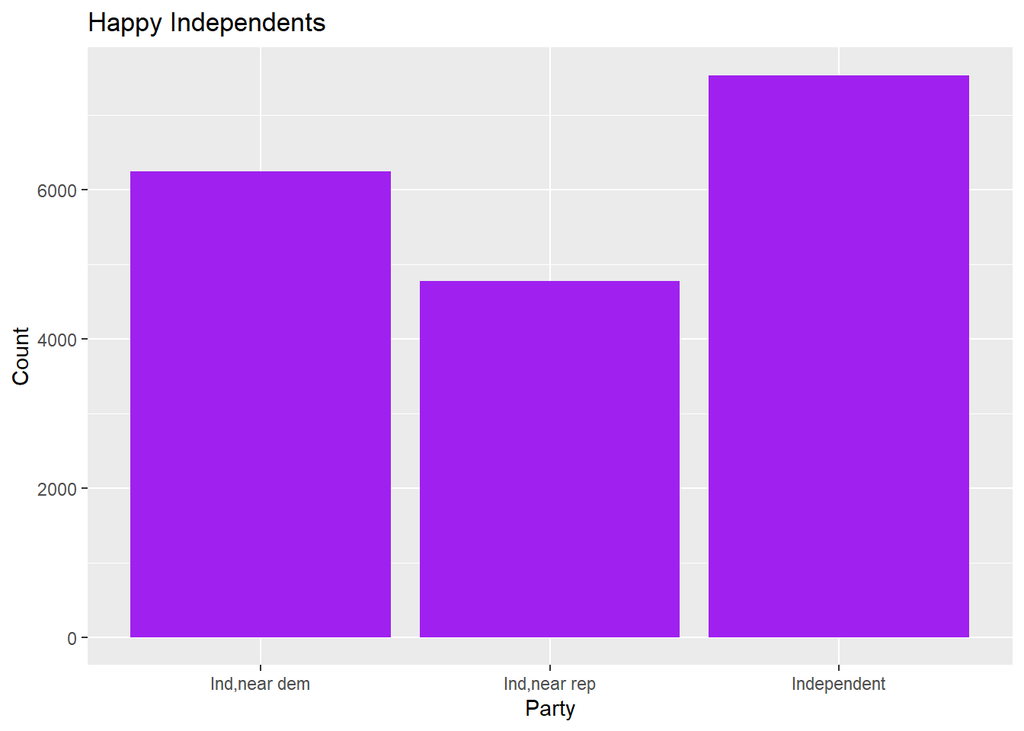

```r
ggplot(dfiHappy, aes(x=party)) + geom_bar(fill="purple") + ggtitle("Happy Independents")+xlab("Party")+ylab("Count")
```

```r
dfiNotHappy <- dfNotHappy %>% group_by(marital) %>% filter(party=="Independent" | party=="Ind,near rep" | party=="Ind,near dem")
dfiNotHappy
```

```
## # A tibble: 3,022 x 9
## # Groups:   marital [5]
##     year    id hours    marital   yearSchool sex   party  happiness  ballotUsed
##    <dbl> <dbl> <chr>    <chr>     <chr>      <chr> <chr>  <chr>      <chr>
##  1  1972     1 Not app~ Never ma~ 16         Fema~ Ind,n~ Not too h~ Not applic~
##  2  1972     7 Not app~ Divorced  13         Male  Ind,n~ Not too h~ Not applic~
##  3  1972     8 Not app~ Never ma~ 16         Male  Ind,n~ Not too h~ Not applic~
##  4  1972    74 Not app~ Married   11         Fema~ Indep~ Not too h~ Not applic~
##  5  1972   118 Not app~ Separated 11         Fema~ Indep~ Not too h~ Not applic~
##  6  1972   128 Not app~ Married   12         Fema~ Ind,n~ Not too h~ Not applic~
##  7  1972   131 Not app~ Married   6          Male  Ind,n~ Not too h~ Not applic~
##  8  1972   143 Not app~ Married   14         Male  Indep~ Not too h~ Not applic~
##  9  1972   191 Not app~ Married   15         Male  Ind,n~ Not too h~ Not applic~
## 10  1972   246 Not app~ Married   9          Fema~ Ind,n~ Not too h~ Not applic~
## # ... with 3,012 more rows
```

```r
i2 <- dfiNotHappy %>% summarize(totalNotHappyI = n())
i2
```

```
## # A tibble: 5 x 2
##   marital       totalNotHappyI
##   <chr>                  <int>
## 1 Divorced                 569
## 2 Married                  931
## 3 Never married            967
## 4 Separated                243
## 5 Widowed                  312
```

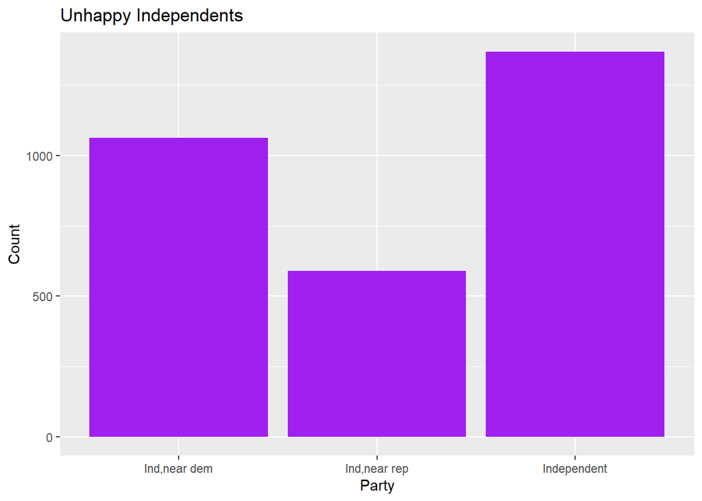

```r
ggplot(dfiNotHappy, aes(x=party)) + geom_bar(fill="purple") + ggtitle("Unhappy Independents")+xlab("Party")+ylab("Count")
```

```r
dfrHappy <- dfHappy %>% group_by(marital) %>% filter(party=="Strong republican" | party=="Not str republican")
r1 <- dfrHappy %>% summarize(totalHappyR = n())
r1
```

```
## # A tibble: 5 x 2
##   marital       totalHappyR
##   <chr>               <int>
## 1 Divorced             1381
## 2 Married              8661
## 3 Never married        2116
## 4 Separated             243
## 5 Widowed              1288
```

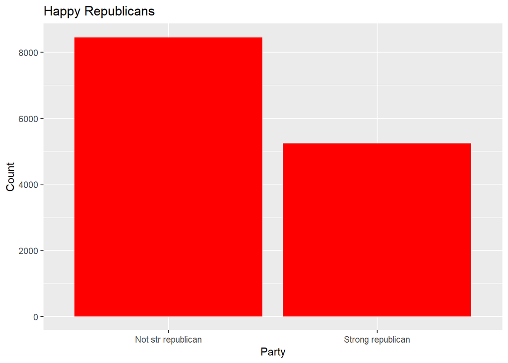

```r
ggplot(dfrHappy, aes(x=party)) + geom_bar(fill="red") + ggtitle("Happy Republicans")+xlab("Party")+ylab("Count")
```

```r
dfrNotHappy <- dfNotHappy %>% group_by(marital) %>% filter(party=="Strong republican" | party=="Not str republican")
r2 <- dfrNotHappy %>% summarize(totalNotHappyR = n())
r2
```

```
## # A tibble: 5 x 2
##   marital       totalNotHappyR
##   <chr>                  <int>
## 1 Divorced                 249
## 2 Married                  452
## 3 Never married            262
## 4 Separated                 85
## 5 Widowed                  262
```

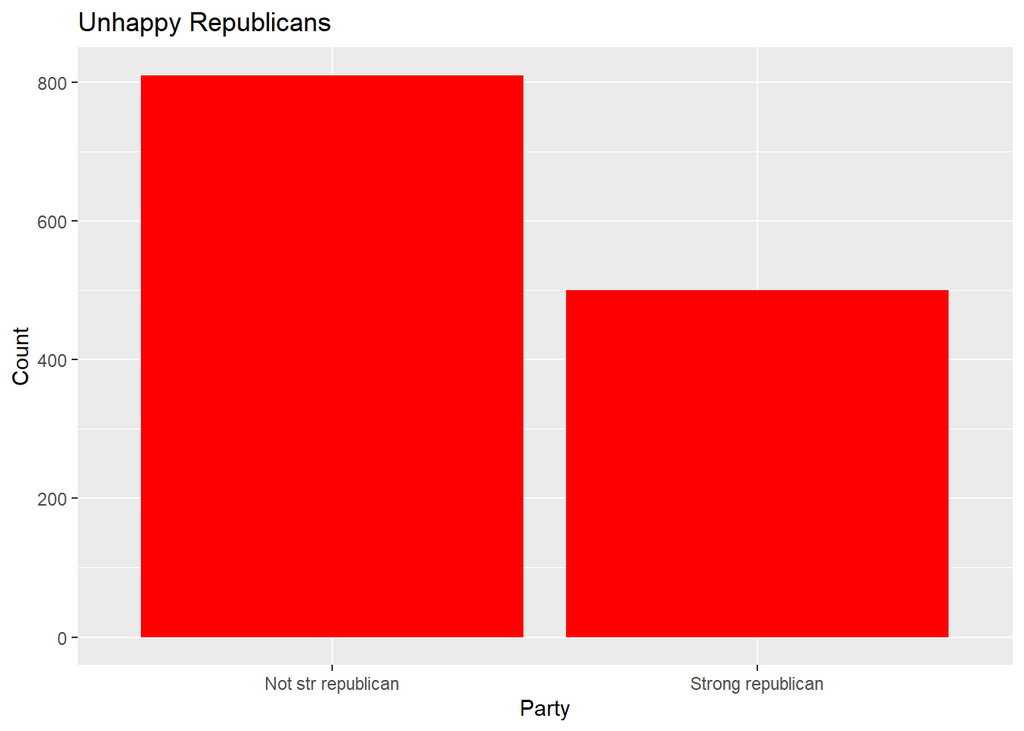

```r
ggplot(dfrNotHappy, aes(x=party)) + geom_bar(fill="red") + ggtitle("Unhappy Republicans")+xlab("Party")+ylab("Count")
```

```r
dfdHappy <- dfHappy %>% group_by(marital) %>% filter(party=="Strong democrat" | party=="Not str democrat")
d1 <- dfdHappy %>% summarize(totalHappyR = n())
d1
```

```
## # A tibble: 5 x 2
##   marital       totalHappyR
##   <chr>               <int>
## 1 Divorced             2266
## 2 Married             10120
## 3 Never married        3828
## 4 Separated             633
## 5 Widowed              2133
```

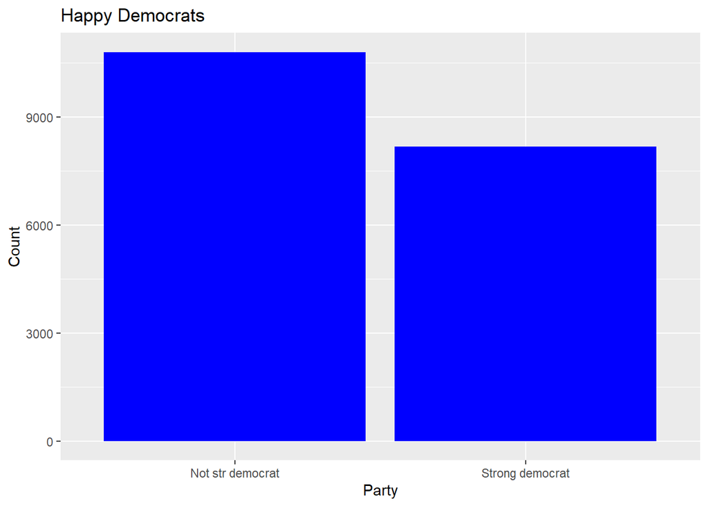

```r
ggplot(dfdHappy, aes(x=party)) + geom_bar(fill="blue") + ggtitle("Happy Democrats")+xlab("Party")+ylab("Count")
```

```r
dfdNotHappy <- dfNotHappy %>% group_by(marital) %>% filter(party=="Strong democrat" | party=="Not str democrat")
d2 <- dfdNotHappy %>% summarize(totalNotHappyR = n())
d2
```

```
## # A tibble: 5 x 2
##   marital       totalNotHappyR
##   <chr>                  <int>
## 1 Divorced                 586
## 2 Married                  983
## 3 Never married            751
## 4 Separated                251
## 5 Widowed                  542
```

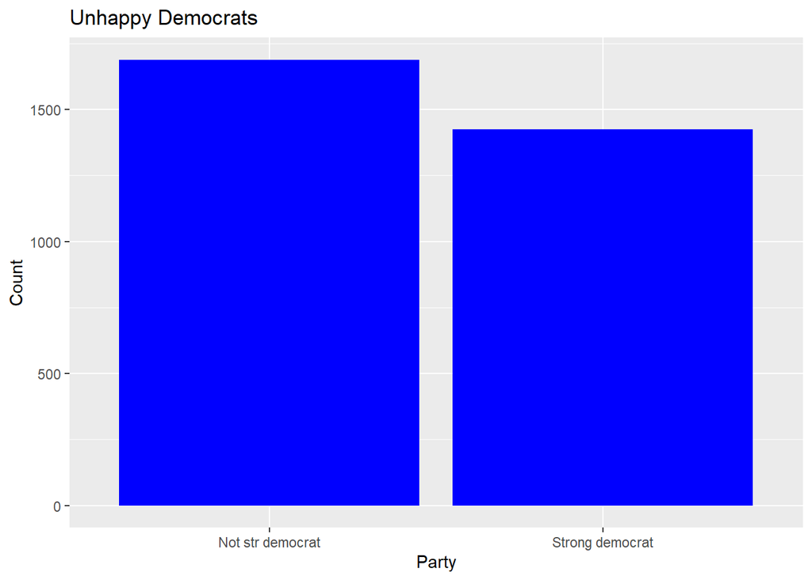

```r
ggplot(dfdNotHappy, aes(x=party)) + geom_bar(fill="blue") + ggtitle("Unhappy Democrats")+xlab("Party")+ylab("Count")
```

These graphs show the happiness and unhappiness of the different parties, which are Democrats, Republicans, and Independents. The republicans actually have the best happy to not happy ratio at 10 happy to every 1 not happy, the democrats and independents are just slightly behind with a ratio of around 6 to 1.

Question #5

```r
df5 <- as.data.frame(dat)
df5 <- filter(df5, !is.na(yearSchool) & yearSchool != 'No answer' & yearSchool != "Don't know" & yearSchool != "NA" )
unique(df5$yearSchool)
```

```
##  [1] "16" "10" "12" "17" "14" "13" "6"  "9"  "8"  "11" "7"  "15" "20" "18" "3"
## [16] "2"  "4"  "5"  "19" "1"  "0"
```

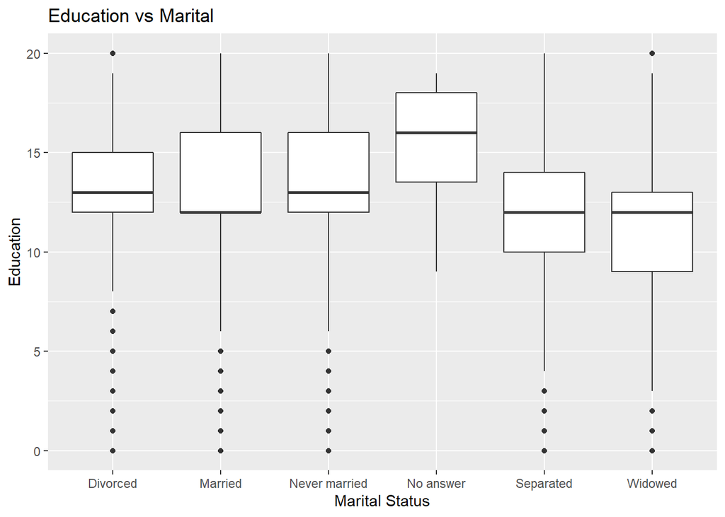

```r
df5$yearSchool <- as.numeric(df5$yearSchool)

ggplot(data = df5, aes(x = marital, y = yearSchool)) + geom_boxplot() + ggtitle("Education vs Marital") + xlab("Marital Status") + ylab("Education")
```

Education doesn’t have much of an effect on the marital status of someone. All of the educations based off marital status’s are very close so it’s hard to say there is any trend, but the best conclusion would be that education isn’t affecting whether people are getting married and there are other factors influencing that.

Question #6a

```r
df6 <- select(dat, hours, happiness)
df6$hours <- as.numeric(df6$hours)
```

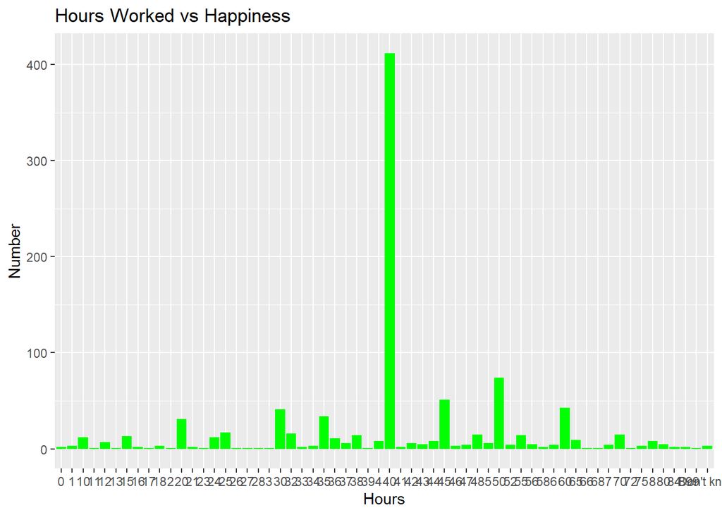

```r
dfHappy <- df3 %>% group_by(hours) %>% filter(happiness=="Pretty happy" | happiness=="Very happy") %>% filter(hours!="Not applicable" & hours!="No answer")
dfNotHappy <- df3 %>% group_by(hours) %>% filter(happiness=="Not too happy") %>% filter(hours !="Not applicable" & hours!="No answer")

notHappy <- dfNotHappy %>% group_by(hours) %>% summarize(totalUnhappy = n())

happy <- dfHappy %>% group_by(hours) %>% summarize(totalHappy = n())

ggplot(dfHappy, aes(x= hours)) + geom_bar(fill="green") + ggtitle("Hours Worked vs Happiness")+xlab("Hours")+ylab("Number")
```

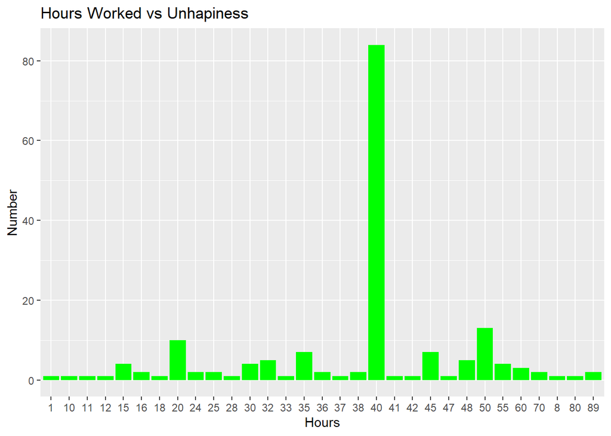

```r
ggplot(dfNotHappy, aes(x=hours)) + geom_bar(fill="green")  + ggtitle("Hours Worked vs Unhapiness")+xlab("Hours")+ylab("Number")
```

Looking at the we can see that there are a lot more people happy with working around 40 hours a week and a lot less people who aren’t happy with it. This would indicate that the average person is more happy to work 40 hours a week and would be less interested in working very little.

Question #6b

```r
df6 <- select(dat, yearSchool, happiness)
df6$yearSchool <- as.numeric(df6$yearSchool)
```

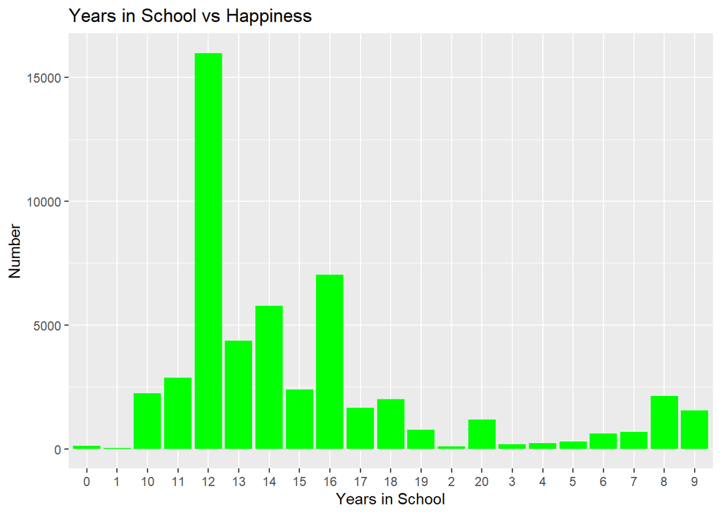

```r
dfHappy <- df3 %>% group_by(yearSchool) %>% filter(happiness=="Pretty happy" | happiness=="Very happy") %>% filter(yearSchool != 'No answer' & yearSchool != "Don't know" & yearSchool != "NA" )

dfNotHappy <- df3 %>% group_by(yearSchool) %>% filter(happiness=="Not too happy") %>% filter(yearSchool != 'No answer' & yearSchool != "Don't know" & yearSchool != "NA" )

notHappy <- dfNotHappy %>% group_by(yearSchool) %>% summarize(totalUnhappy = n())

happy <- dfHappy %>% group_by(yearSchool) %>% summarize(totalHappy = n())

ggplot(dfHappy, aes(x= yearSchool)) + geom_bar(fill="green") + ggtitle("Years in School vs Happiness")+xlab("Years in School")+ylab("Number")
```

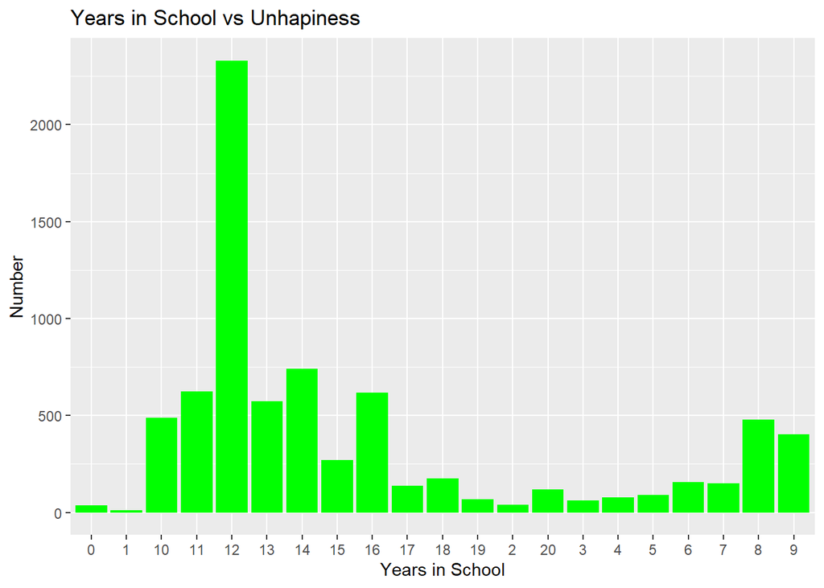

```r
ggplot(dfNotHappy, aes(x = yearSchool)) + geom_bar(fill="green") + ggtitle("Years in School vs Unhapiness")+xlab("Years in School")+ylab("Number")
```

This shows that there are a lot more people happy with all levels of education that there are people that are unhappy. For reference the graph shows about 15,000 people for 12 years and happy, but only 2,000 people for 12 years and unhappy. That would mean that for every 17,000 people, 15,000 end up being happy, which is a very high amount. There are similar trends and ratio’s amoung all other years of education when looking at happy vs unhappy as well.